# DeX Internal Benchmarking

# Prerequisite

This R notebook allows to generate DeX Benchmarking comparing the DeX across an organization between different **Entities**, **OS**, **Devices**, **Model** and **Types**.

In order to get the data, run the investigation *./all_dex_info.xml* in your customer’s instance.

For running the R code, the Tidyverse package is needed.

Loading the data into a tibble. In that case the csv generated used the tabulation separator. Adapt the delim parameter to your specific use case (coma, semicolon etc).

```r
df <- read_delim(file = "./data-raw/data_sample.csv", delim = "\t")
head(df)
```

| Platform | Name | Entity | Last IP address | Device model | Device type | OS version and architecture | OS name | Total RAM [bytes] | CPU model | Hard disks | DXS - Device (DXS - Device) | DXS - Web browsing (DXS - Web browsing) | DXS - Security (DXS - Security) | DXS - Productivity (DXS - Productivity) | DXS - Business apps (DXS - Business apps) | Device (sentiment) (DXS - User sentiments) | Web browsing (sentiment) (DXS - User sentiments) | Productivity (sentiment) (DXS - User sentiments) | Security (sentiment) (DXS - User sentiments) | Employee Satisfaction (DXS - User sentiments) | Business apps (sentiment) (DXS - User sentiments) |
| --- | --- | --- | --- | --- | --- | --- | --- | --- | --- | --- | --- | --- | --- | --- | --- | --- | --- | --- | --- | --- | --- |
| Windows | 1KBKING-D1 | Houston - 910 Corp (TX) | 10.132.28.114 | OptiPlex 9010 | desktop | Windows 7 Professional SP1 (64 bits) | Windows 7 | 8589934592 | Intel Core i7-3770 CPU @ 3.40GHz | Seagate (232.9GB, 100% S.M.A.R.T.) | NA | NA | NA | NA | NA | NA | NA | NA | NA | NA | NA |
| Windows | 1KBSINGLETO-D1 | Houston - 910 Corp (TX) | 10.133.28.51 | OptiPlex 9010 | desktop | Windows 7 Professional SP1 (64 bits) | Windows 7 | 8589934592 | Intel Core i7-3770 CPU @ 3.40GHz | Seagate (232.9GB, 100% S.M.A.R.T.) | NA | NA | NA | NA | NA | NA | NA | NA | NA | NA | NA |
| Windows | 1KJBRANDENB-D1 | Houston - 910 Corp (TX) | 10.132.36.94 | OptiPlex 9010 | desktop | Windows 7 Professional SP1 (64 bits) | Windows 7 | 12884901888 | Intel Core i7-3770 CPU @ 3.40GHz | Seagate (232.9GB, 100% S.M.A.R.T.) | NA | NA | NA | NA | NA | NA | NA | NA | NA | NA | NA |
| Windows | 1KMKUMAR-D1 | Houston - 910 Corp (TX) | 10.132.36.89 | OptiPlex 9010 | desktop | Windows 7 Professional SP1 (64 bits) | Windows 7 | 8589934592 | Intel Core i7-3770 CPU @ 3.40GHz | Seagate (232.9GB, 100% S.M.A.R.T.) | NA | NA | NA | NA | NA | NA | NA | NA | NA | NA | NA |
| Windows | 1KMMEJIA-D1 | Houston - 910 Corp (TX) | 10.132.253.36 | OptiPlex 990 | desktop | Windows 7 Professional SP1 (64 bits) | Windows 7 | 12884901888 | Intel Core i5-2400 CPU @ 3.10GHz | Seagate (232.9GB, 100% S.M.A.R.T.) | NA | NA | NA | NA | NA | NA | NA | NA | NA | NA | NA |
| Windows | 1KMMEJIA-L1 | - | 73.115.151.178 | Latitude E6520 | laptop | Windows 7 Professional SP1 (64 bits) | Windows 7 | 4294967296 | Intel Core i5-2520M CPU @ 2.50GHz | Samsung (119.2GB, 90% S.M.A.R.T.), HP OfficeJet Pro 69 USB Device (0B), Verbatim STORE N GO USB Device (7.3GB), Western Digital (931.5GB) | NA | NA | NA | NA | NA | NA | NA | NA | NA | NA | NA |

We rename the unknown entities (-) to “Unknown (-)”.

```r
# We test if there are entities with '-', if yes we rename it with 'Unknown' instead
if (nrow(filter(df, grepl("^-$",Entity))) > 0){
  df <- df %>%
    mutate(Entity = replace(Entity, which(grepl("^-$", Entity)),"Unknown"))
}
```

## DeX by Entity

We organize and tidy the tidy the data.

```r
df.tidy <- df %>%
  group_by(Entity) %>%
  summarize(count_devices = n(),
            dxs_device = mean(`DXS - Device (DXS - Device)`, na.rm = TRUE),
            dxs_browsing = mean(`DXS - Web browsing (DXS - Web browsing)`, na.rm = TRUE),
            dxs_security = mean(`DXS - Security (DXS - Security)`, na.rm = TRUE),
            dxs_productivity = mean(`DXS - Productivity (DXS - Productivity)`, na.rm = TRUE),
            dxs_business_apps = mean(`DXS - Business apps (DXS - Business apps)`, na.rm = TRUE)) %>%
  arrange(desc(count_devices)) %>%
  # We keep only entities with more than 100 devices
  filter(count_devices > 100)
  head(df.tidy)
```

| Entity | count_devices | dxs_device | dxs_browsing | dxs_security | dxs_productivity | dxs_business_apps |
| --- | --- | --- | --- | --- | --- | --- |
| Houston - 910 Corp (TX) | 1548 | 5.322481 | 9.947863 | 9.750378 | 8.965833 | 8.605578 |
| Unknown | 1251 | 5.235181 | 9.969911 | 9.495575 | 8.301750 | 6.528466 |
| Princeton (NJ) | 392 | 5.771814 | 9.961514 | 9.701493 | 9.045002 | 8.973707 |
| VPN (TX) | 359 | 5.178291 | 9.961293 | 9.588235 | 8.244065 | 6.587438 |
| Houston - 910 PCI (TX) | 311 | 4.364563 | 9.651127 | 9.933333 | 9.920113 | 8.941657 |
| Guadalajara (MX) | 272 | 3.501339 | 9.813383 | 9.568627 | 8.521600 | 5.387386 |

We convert tibble to the long format (more tidyverse friendly format).

```r
df.long <- gather(df.tidy, type, value, -Entity, -count_devices)
head(df.long)
```

| Entity | count_devices | type | value |
| --- | --- | --- | --- |
| Houston - 910 Corp (TX) | 1548 | dxs_device | 5.322481 |
| Unknown | 1251 | dxs_device | 5.235181 |
| Princeton (NJ) | 392 | dxs_device | 5.771814 |
| VPN (TX) | 359 | dxs_device | 5.178291 |
| Houston - 910 PCI (TX) | 311 | dxs_device | 4.364563 |
| Guadalajara (MX) | 272 | dxs_device | 3.501339 |

We plot the results in a barplot:

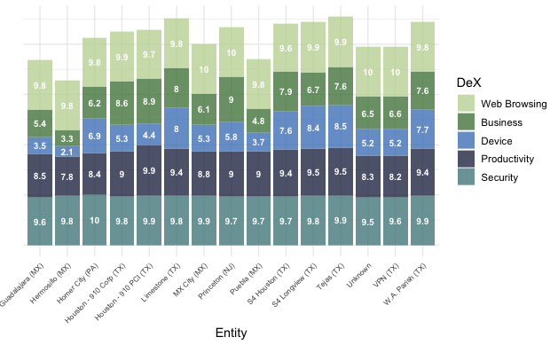

## DeX by OS

We organize and tidy the tidy the data.

```r
df.os.tidy <- df %>%
  group_by(`OS name`) %>%
  summarize(count_devices = n(),
            dxs_device = mean(`DXS - Device (DXS - Device)`, na.rm = TRUE),
            dxs_browsing = mean(`DXS - Web browsing (DXS - Web browsing)`, na.rm = TRUE),
            dxs_security = mean(`DXS - Security (DXS - Security)`, na.rm = TRUE),
            dxs_productivity = mean(`DXS - Productivity (DXS - Productivity)`, na.rm = TRUE),
            dxs_business = mean(`DXS - Business apps (DXS - Business apps)`, na.rm = TRUE)) %>%
  arrange(desc(count_devices))
head(df.os.tidy)
```

| OS name | count_devices | dxs_device | dxs_browsing | dxs_security | dxs_productivity | dxs_business |
| --- | --- | --- | --- | --- | --- | --- |
| Windows 10 | 6596 | 5.860153 | 9.890134 | 9.736713 | 8.800051 | 7.189156 |
| Windows 7 | 604 | 4.678540 | 9.942369 | 9.652406 | 8.825614 | 5.953041 |

We convert tibble to the long format (more tidyverse friendly format).

```r
df.os.long <- gather(df.os.tidy, type, value, -`OS name`, -count_devices)
head(df.os.long)
```

| OS name | count_devices | type | value |
| --- | --- | --- | --- |
| Windows 10 | 6596 | dxs_device | 5.860153 |
| Windows 7 | 604 | dxs_device | 4.678540 |
| Windows 10 | 6596 | dxs_browsing | 9.890134 |
| Windows 7 | 604 | dxs_browsing | 9.942369 |
| Windows 10 | 6596 | dxs_security | 9.736713 |
| Windows 7 | 604 | dxs_security | 9.652406 |

We plot the results in a barplot.

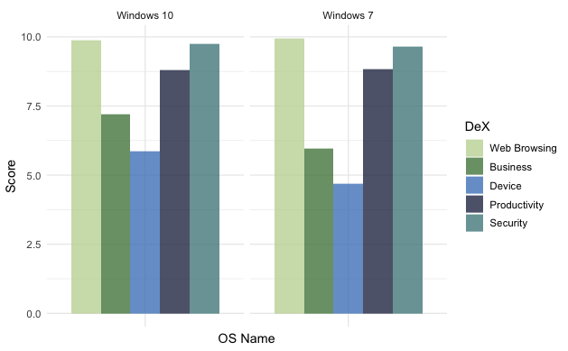

## DeX by Device Type

We organize and tidy the tidy the data.

```r
df.type.tidy <- df %>%
  group_by(`Device type`) %>%
  summarize(count_devices = n(),
            dxs_device = mean(`DXS - Device (DXS - Device)`, na.rm = TRUE),
            dxs_browsing = mean(`DXS - Web browsing (DXS - Web browsing)`, na.rm = TRUE),
            dxs_security = mean(`DXS - Security (DXS - Security)`, na.rm = TRUE),
            dxs_productivity = mean(`DXS - Productivity (DXS - Productivity)`, na.rm = TRUE),
            dxs_business = mean(`DXS - Business apps (DXS - Business apps)`, na.rm = TRUE)) %>%
  arrange(desc(count_devices))
head(df.type.tidy)
```

| Device type | count_devices | dxs_device | dxs_browsing | dxs_security | dxs_productivity | dxs_business |
| --- | --- | --- | --- | --- | --- | --- |
| desktop | 4000 | 6.461140 | 9.848520 | 9.792633 | 8.983195 | 6.992192 |
| laptop | 3200 | 4.923701 | 9.939316 | 9.652975 | 8.608078 | 7.285530 |

We convert tibble to the long format (more tidyverse friendly format).

```r
df.type.long <- gather(df.type.tidy, type, value, -`Device type`, -count_devices)
head(df.type.long)
```

| Device type | count_devices | type | value |
| --- | --- | --- | --- |
| desktop | 4000 | dxs_device | 6.461140 |
| laptop | 3200 | dxs_device | 4.923701 |
| desktop | 4000 | dxs_browsing | 9.848520 |
| laptop | 3200 | dxs_browsing | 9.939316 |
| desktop | 4000 | dxs_security | 9.792633 |
| laptop | 3200 | dxs_security | 9.652975 |

We plot the results in a barplot.

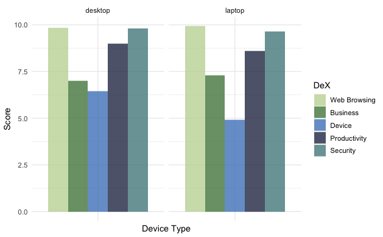

## DeX by Device Model

We organize and tidy the tidy the data.

```r
df.model.tidy <- df %>%
  group_by(`Device model`) %>%
  summarize(count_devices = n(),
            dxs_device = mean(`DXS - Device (DXS - Device)`, na.rm = TRUE),
            dxs_browsing = mean(`DXS - Web browsing (DXS - Web browsing)`, na.rm = TRUE),
            dxs_security = mean(`DXS - Security (DXS - Security)`, na.rm = TRUE),
            dxs_productivity = mean(`DXS - Productivity (DXS - Productivity)`, na.rm = TRUE),
            dxs_business = mean(`DXS - Business apps (DXS - Business apps)`, na.rm = TRUE)) %>%
  arrange(desc(count_devices)) %>%
  # We keep only entities with more than 100 devices
  filter(count_devices > 100)
head(df.model.tidy)
```

| Device model | count_devices | dxs_device | dxs_browsing | dxs_security | dxs_productivity | dxs_business |
| --- | --- | --- | --- | --- | --- | --- |
| OptiPlex 9020 | 1716 | 6.350026 | 9.841379 | 9.830402 | 8.975560 | 7.118906 |
| OptiPlex 7010 | 1145 | 7.251017 | 9.828112 | 9.746094 | 9.160315 | 7.491552 |
| Latitude E7440 | 697 | 5.643983 | 9.938847 | 9.594814 | 8.619608 | 7.629395 |
| Latitude 7490 | 692 | 3.883144 | 9.948417 | 9.969466 | 8.633026 | 7.373911 |
| OptiPlex 3020 | 288 | 3.308931 | 9.788890 | 9.600000 | 8.673042 | 5.343207 |
| Latitude E7450 | 259 | 6.575904 | 9.979300 | 9.655172 | 8.582449 | 7.143711 |

We convert tibble to the long format (more tidyverse friendly format).

```r
df.model.long <- gather(df.model.tidy, type, value, -`Device model`, -count_devices)
head(df.model.long)
```

| Device model | count_devices | type | value |
| --- | --- | --- | --- |
| OptiPlex 9020 | 1716 | dxs_device | 6.350026 |
| OptiPlex 7010 | 1145 | dxs_device | 7.251017 |
| Latitude E7440 | 697 | dxs_device | 5.643983 |
| Latitude 7490 | 692 | dxs_device | 3.883144 |
| OptiPlex 3020 | 288 | dxs_device | 3.308931 |
| Latitude E7450 | 259 | dxs_device | 6.575904 |

We plot the results in a barplot:

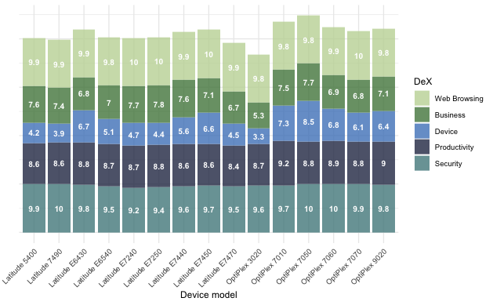